# Actividad 4

## Regresión Multivariada

### Selección de variables predictoras

Dr. Hugo García Tecocoatzi

```python
#  Importar bibliotecas necesarias
import numpy as np
import pandas as pd
import matplotlib.pyplot as plt
import seaborn as sns
import warnings
warnings.filterwarnings('ignore')

from sklearn.model_selection import train_test_split
from sklearn.linear_model import LinearRegression
from sklearn import metrics
from sklearn.feature_selection import f_regression, SelectKBest

import statsmodels.api as sm
from statsmodels.stats.outliers_influence import variance_inflation_factor

%matplotlib inline
```

Vamos a generar datos sintéticos para la actividad:

```python
#  Simulamos un problema de bienes raíces
np.random.seed(42)
n = 200

# Variables predictoras
Tamaño = np.random.randn(n) * 10 + 50           # Tamaño en m²
Habitaciones = Tamaño + np.random.randn(n) * 3  # Número de habitaciones (correlacionado)
Antigüedad = np.random.randn(n) * 5 + 20        # Antigüedad en años
Ubicación = np.random.randn(n) * 3 + 5          # Calidad de ubicación (1-10)

# Variable respuesta (precio)
Precio = 500 + 25*Tamaño + 15*Habitaciones - 8*Antigüedad + 30*Ubicación + np.random.randn(n)*50

# Crear DataFrame
df = pd.DataFrame({
    'Tamaño': Tamaño,
    'Habitaciones': Habitaciones,
    'Antigüedad': Antigüedad,
    'Ubicación': Ubicación,
    'Precio': Precio
})


print(f"Forma del dataset: {df.shape}")
print("\nPrimeras 5 filas:")
df.head()
```

```
Forma del dataset: (200, 5)

Primeras 5 filas:
```

|  | Tamaño | Habitaciones | Antigüedad | Ubicación | Precio |
| --- | --- | --- | --- | --- | --- |
| 0 | 54.967142 | 56.040504 | 12.027862 | 7.270966 | 2883.606365 |
| 1 | 48.617357 | 50.299711 | 17.003125 | 2.233504 | 2375.107469 |
| 2 | 56.476885 | 59.726039 | 20.026218 | 7.608818 | 2880.673545 |
| 3 | 65.230299 | 68.391705 | 20.234903 | 9.066914 | 3243.647454 |
| 4 | 47.658466 | 43.525458 | 17.749673 | 6.240305 | 2367.830477 |

```python
# Estadísticas descriptivas
print("ESTADÍSTICAS DESCRIPTIVAS\n")
print(df.describe().round(2))
```

```
ESTADÍSTICAS DESCRIPTIVAS

       Tamaño  Habitaciones  Antigüedad  Ubicación   Precio
count  200.00        200.00      200.00     200.00   200.00
mean    49.59         49.85       19.57       5.03  2488.20
std      9.31         10.03        4.97       3.06   403.41
min     23.80         20.86        7.64      -3.09  1203.80
25%     42.95         43.03       16.03       2.88  2199.68
50%     49.96         50.35       19.61       5.07  2494.96
75%     55.01         55.75       22.86       7.06  2744.40
max     77.20         77.07       35.39      12.90  3663.00
```

```python
# Matriz de correlación detallada
print("\nMATRIZ DE CORRELACIÓN\n")
print(df.corr().round(3))
```

```
MATRIZ DE CORRELACIÓN

              Tamaño  Habitaciones  Antigüedad  Ubicación  Precio
Tamaño         1.000         0.956      -0.134      0.065   0.958
Habitaciones   0.956         1.000      -0.134      0.031   0.936
Antigüedad    -0.134        -0.134       1.000      0.106  -0.199
Ubicación      0.065         0.031       0.106      1.000   0.287
Precio         0.958         0.936      -0.199      0.287   1.000
```

### Preguntas

1. ¿Qué variables tienen mayor correlación con el Precio? Las varaibles que tienen mayor correlación con el precio son el tamaño y las habitaciones (ambas positivas)
2. ¿Hay variables altamente correlacionadas entre sí? ¿Cuáles? Si hay, y las que están correlacionadas entre si según la matriz de correlación son: Precio-Tamaño Precio-Habitaciones Habitaciones-Tamaño
3. ¿Cómo crees que afecta cada variable al precio?" Según la matriz de correlación las varaibles de tamaño, habitaciones, antigüedad y ubicación afectan a la varaible de precio de la siguiente forma: a) Tamaño, tiene una correlación postiva de 0.958 (alta), por lo que indica una relación directamente proporcional. b) Habitaciones, tiene una correlación positiva de 0.936 (alta), por lo que indica una relación directamente proporcional c) Antigüedad, tiene una correlación negativa de -0.199 (de media a baja), lo que indica que las variables son iversamente proporcionales d) Ubicación, tiene una correlación positiva de 0.287 (media a baja), lo que indica que las varaibles son directamente proporcionales

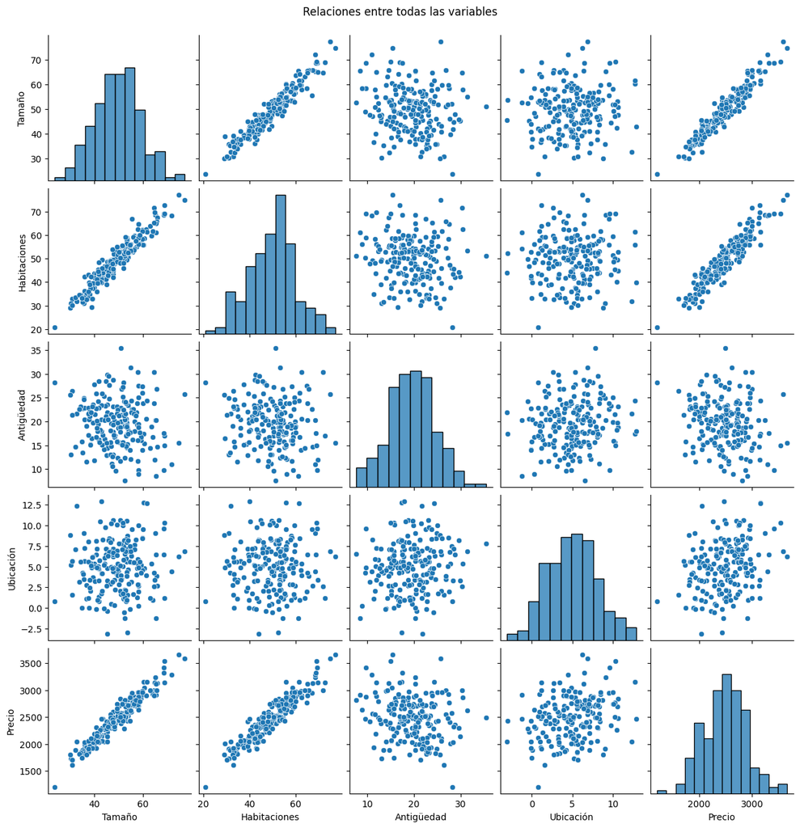

```python
# Pairplot de variables
sns.pairplot(df)
plt.suptitle('Relaciones entre todas las variables', y=1.02)
plt.show()
```

```python
#  Dividir datos en entrenamiento y prueba
X = df.drop('Precio', axis=1)
y = df['Precio']

X_train, X_test, y_train, y_test = train_test_split(
    X, y, test_size=0.3, random_state=42
)

print(f"Tamaño de entrenamiento: {X_train.shape[0]} muestras")
print(f"Tamaño de prueba: {X_test.shape[0]} muestras")
```

```
Tamaño de entrenamiento: 140 muestras
Tamaño de prueba: 60 muestras
```

```python
# Entrenar modelo de regresión lineal con todas las variables
modelo = LinearRegression()
modelo.fit(X_train, y_train)

# Mostrar coeficientes
coeficientes = pd.DataFrame({
    'Variable': X.columns,
    'Coeficiente': modelo.coef_
})
print("=== COEFICIENTES DEL MODELO ===\n")
print(coeficientes)
print(f"\nIntercept (término constante): {modelo.intercept_:.4f}")
```

```
=== COEFICIENTES DEL MODELO ===

       Variable  Coeficiente
0        Tamaño    28.191932
1  Habitaciones    12.110154
2    Antigüedad    -7.294327
3     Ubicación    32.566862

Intercept (término constante): 467.3919
```

```python
# Evaluar modelo completo
y_pred = modelo.predict(X_test)

MAE = metrics.mean_absolute_error(y_test, y_pred)
MSE = metrics.mean_squared_error(y_test, y_pred)
RMSE = np.sqrt(MSE)
R2 = metrics.r2_score(y_test, y_pred)

print("=== MÉTRICAS DE EVALUACIÓN ===\n")
print(f"Error Absoluto Medio (MAE): {MAE:.4f}")
print(f"Error Cuadrático Medio (MSE): {MSE:.4f}")
print(f"Raíz del Error Cuadrático Medio (RMSE): {RMSE:.4f}")
print(f"R² (Coeficiente de Determinación): {R2:.4f}")
```

```
=== MÉTRICAS DE EVALUACIÓN ===

Error Absoluto Medio (MAE): 39.1850
Error Cuadrático Medio (MSE): 2274.3596
Raíz del Error Cuadrático Medio (RMSE): 47.6902
R² (Coeficiente de Determinación): 0.9828
```

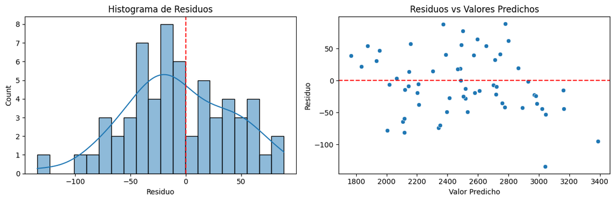

```
Media de residuos: -6.4355
Desviación estándar de residuos: 47.6528
```

```python
# Análisis de residuos
residuos = y_test - y_pred

plt.figure(figsize=(12, 4))

plt.subplot(1, 2, 1)
sns.histplot(residuos, kde=True, bins=20)
plt.axvline(x=0, color='r', linestyle='--')
plt.title('Histograma de Residuos')
plt.xlabel('Residuo')

plt.subplot(1, 2, 2)
sns.scatterplot(x=y_pred, y=residuos)
plt.axhline(y=0, color='r', linestyle='--')
plt.title('Residuos vs Valores Predichos')
plt.xlabel('Valor Predicho')
plt.ylabel('Residuo')

plt.tight_layout()
plt.show()

print(f"Media de residuos: {residuos.mean():.4f}")
print(f"Desviación estándar de residuos: {residuos.std():.4f}")
```

```python
# Cálculo del VIF (Factor de Inflación de la Varianza)
X_constant = sm.add_constant(X)
vif_data = pd.DataFrame()
vif_data["Variable"] = X_constant.columns
vif_data["VIF"] = [variance_inflation_factor(X_constant.values, i)
                   for i in range(X_constant.shape[1])]

print("=== FACTOR DE INFLACIÓN DE LA VARIANZA (VIF) ===\n")
print(vif_data)
print("\n Recuerda:")
print("- VIF > 5: indica alta multicolinealidad")
print("- VIF > 10: indica multicolinealidad severa")
```

```
=== FACTOR DE INFLACIÓN DE LA VARIANZA (VIF) ===

       Variable        VIF
0         const  52.311219
1        Tamaño  11.780300
2  Habitaciones  11.727624
3    Antigüedad   1.032297
4     Ubicación   1.029735

 Recuerda:
- VIF > 5: indica alta multicolinealidad
- VIF > 10: indica multicolinealidad severa
```

```python
#  Selección hacia adelante (Forward Selection)
def forward_selection(X, y, threshold=0.05):
    """
    Selección de variables hacia adelante basada en p-valor
    """
    included = []
    while True:
        changed = False
        excluded = list(set(X.columns) - set(included))
        new_pval = pd.Series(index=excluded, dtype=float)

        for new_col in excluded:
            model = sm.OLS(y, sm.add_constant(pd.DataFrame(X[included + [new_col]]))).fit()
            new_pval[new_col] = model.pvalues[new_col]

        best_pval = new_pval.min()
        if best_pval < threshold:
            best_feature = new_pval.idxmin()
            included.append(best_feature)
            changed = True

        if not changed:
            break

    return included

print("=== SELECCIÓN HACIA ADELANTE ===\n")
variables_seleccionadas = forward_selection(X, y)
print(f"Variables seleccionadas: {variables_seleccionadas}")
```

```
=== SELECCIÓN HACIA ADELANTE ===

Variables seleccionadas: ['Tamaño', 'Ubicación', 'Antigüedad', 'Habitaciones']
```

```python
# Comparación de modelos con diferentes variables
print("=== COMPARACIÓN DE MODELOS ===\n")

combinaciones = [
    ['Tamaño'],
    ['Tamaño', 'Habitaciones'],
    ['Tamaño', 'Habitaciones', 'Antigüedad'],
    ['Tamaño', 'Habitaciones', 'Antigüedad', 'Ubicación'],
    variables_seleccionadas
]

nombres_combinaciones = [
    'Modelo 1: Tamaño',
    'Modelo 2: Tamaño + Habitaciones',
    'Modelo 3: Tamaño + Habitaciones + Antigüedad',
    'Modelo 4: Modelo completo',
    'Modelo 5: Variables seleccionadas (Forward)'
]

for nombre, vars_list in zip(nombres_combinaciones, combinaciones):
    X_sel = sm.add_constant(X[vars_list])
    model = sm.OLS(y, X_sel).fit()

    print(f"📊 {nombre}")
    print(f"  Variables: {vars_list}")
    print(f"  R² = {model.rsquared:.4f}")
    print(f"  R² ajustado = {model.rsquared_adj:.4f}")
    print(f"  AIC = {model.aic:.2f}")
    print(f"  BIC = {model.bic:.2f}")
    print()
```

```
=== COMPARACIÓN DE MODELOS ===

📊 Modelo 1: Tamaño
  Variables: ['Tamaño']
  R² = 0.9178
  R² ajustado = 0.9174
  AIC = 2470.82
  BIC = 2477.41

📊 Modelo 2: Tamaño + Habitaciones
  Variables: ['Tamaño', 'Habitaciones']
  R² = 0.9228
  R² ajustado = 0.9220
  AIC = 2460.37
  BIC = 2470.26

📊 Modelo 3: Tamaño + Habitaciones + Antigüedad
  Variables: ['Tamaño', 'Habitaciones', 'Antigüedad']
  R² = 0.9276
  R² ajustado = 0.9265
  AIC = 2449.43
  BIC = 2462.63

📊 Modelo 4: Modelo completo
  Variables: ['Tamaño', 'Habitaciones', 'Antigüedad', 'Ubicación']
  R² = 0.9866
  R² ajustado = 0.9863
  AIC = 2113.96
  BIC = 2130.45

📊 Modelo 5: Variables seleccionadas (Forward)
  Variables: ['Tamaño', 'Ubicación', 'Antigüedad', 'Habitaciones']
  R² = 0.9866
  R² ajustado = 0.9863
  AIC = 2113.96
  BIC = 2130.45
```

```python
# Análisis detallado del mejor modelo
print("=== MEJOR MODELO SEGÚN FORWARD SELECTION ===\n")

X_sel = sm.add_constant(X[variables_seleccionadas])
modelo_final = sm.OLS(y, X_sel).fit()
print(modelo_final.summary())
```

```
=== MEJOR MODELO SEGÚN FORWARD SELECTION ===

                            OLS Regression Results
==============================================================================
Dep. Variable:                 Precio   R-squared:                       0.987
Model:                            OLS   Adj. R-squared:                  0.986
Method:                 Least Squares   F-statistic:                     3591.
Date:                Thu, 17 Sep 2026   Prob (F-statistic):          2.30e-181
Time:                        16:23:41   Log-Likelihood:                -1052.0
No. Observations:                 200   AIC:                             2114.
Df Residuals:                     195   BIC:                             2130.
Df Model:                           4
Covariance Type:            nonrobust
================================================================================
                   coef    std err          t      P>|t|      [0.025      0.975]
--------------------------------------------------------------------------------
const          501.7704     24.121     20.803      0.000     454.200     549.341
Tamaño          26.8301      1.233     21.768      0.000      24.399      29.261
Ubicación       32.5091      1.109     29.309      0.000      30.322      34.697
Antigüedad      -7.9921      0.683    -11.694      0.000      -9.340      -6.644
Habitaciones    13.0164      1.141     11.408      0.000      10.766      15.267
==============================================================================
Omnibus:                        0.961   Durbin-Watson:                   1.849
Prob(Omnibus):                  0.618   Jarque-Bera (JB):                0.986
Skew:                           0.044   Prob(JB):                        0.611
Kurtosis:                       2.668   Cond. No.                         537.
==============================================================================

Notes:
[1] Standard Errors assume that the covariance matrix of the errors is correctly specified.
```

```python
# Evaluación del mejor modelo en test
X_train_sel = X_train[variables_seleccionadas]
X_test_sel = X_test[variables_seleccionadas]

modelo_sel = LinearRegression()
modelo_sel.fit(X_train_sel, y_train)

y_pred_sel = modelo_sel.predict(X_test_sel)

MAE_sel = metrics.mean_absolute_error(y_test, y_pred_sel)
MSE_sel = metrics.mean_squared_error(y_test, y_pred_sel)
RMSE_sel = np.sqrt(MSE_sel)
R2_sel = metrics.r2_score(y_test, y_pred_sel)

print("=== COMPARACIÓN DE RENDIMIENTO ===\n")
print("Modelo Completo vs Modelo Seleccionado:")

print(f"\nModelo Completo (todas las variables):")
print(f"  MAE: {MAE:.4f}")
print(f"  RMSE: {RMSE:.4f}")
print(f"  R²: {R2:.4f}")

print(f"\nModelo Seleccionado ({variables_seleccionadas}):")
print(f"  MAE: {MAE_sel:.4f}")
print(f"  RMSE: {RMSE_sel:.4f}")
print(f"  R²: {R2_sel:.4f}")
```

```
=== COMPARACIÓN DE RENDIMIENTO ===

Modelo Completo vs Modelo Seleccionado:

Modelo Completo (todas las variables):
  MAE: 39.1850
  RMSE: 47.6902
  R²: 0.9828

Modelo Seleccionado (['Tamaño', 'Ubicación', 'Antigüedad', 'Habitaciones']):
  MAE: 39.1850
  RMSE: 47.6902
  R²: 0.9828
```

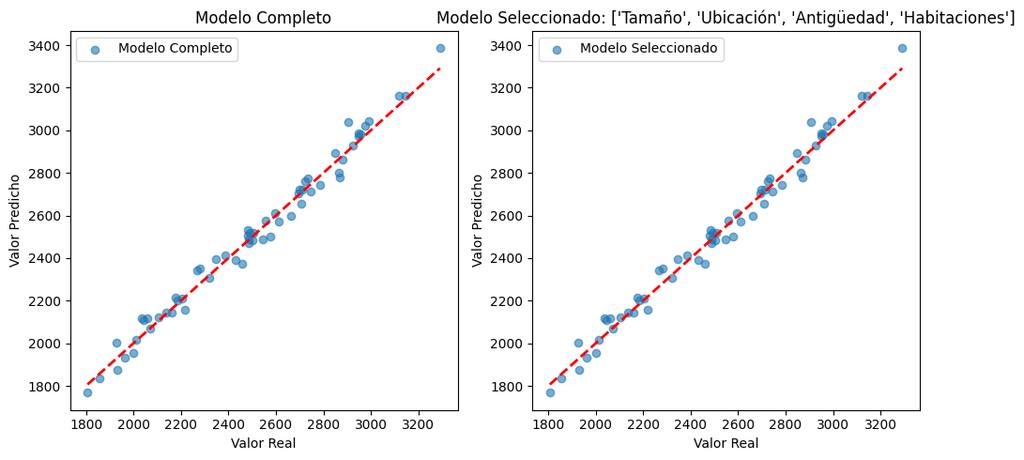

```python
# Visualización del modelo seleccionado
plt.figure(figsize=(10, 5))

plt.subplot(1, 2, 1)
plt.scatter(y_test, y_pred, alpha=0.6, label='Modelo Completo')
plt.plot([y_test.min(), y_test.max()], [y_test.min(), y_test.max()], 'r--', lw=2)
plt.xlabel('Valor Real')
plt.ylabel('Valor Predicho')
plt.title('Modelo Completo')
plt.legend()

plt.subplot(1, 2, 2)
plt.scatter(y_test, y_pred_sel, alpha=0.6, label='Modelo Seleccionado')
plt.plot([y_test.min(), y_test.max()], [y_test.min(), y_test.max()], 'r--', lw=2)
plt.xlabel('Valor Real')
plt.ylabel('Valor Predicho')
plt.title(f'Modelo Seleccionado: {variables_seleccionadas}')
plt.legend()

plt.tight_layout()
plt.show()
```

## Actividad Final

Utiliza este notebook para ver qué varibles debes eliminar de la base de datos de Real Estate

```python
 #se importa la base de datos de real state
real_state=pd.read_csv("realstateact4.csv")
real_state.head(5)
```

|  | No | X1 transaction date | X2 house age | X3 distance to the nearest MRT station | X4 number of convenience stores | X5 latitude | X6 longitude | Y house price of unit area |
| --- | --- | --- | --- | --- | --- | --- | --- | --- |
| 0 | 1 | 2012.917 | 32.0 | 84.87882 | 10 | 24.98298 | 121.54024 | 37.9 |
| 1 | 2 | 2012.917 | 19.5 | 306.59470 | 9 | 24.98034 | 121.53951 | 42.2 |
| 2 | 3 | 2013.583 | 13.3 | 561.98450 | 5 | 24.98746 | 121.54391 | 47.3 |
| 3 | 4 | 2013.500 | 13.3 | 561.98450 | 5 | 24.98746 | 121.54391 | 54.8 |
| 4 | 5 | 2012.833 | 5.0 | 390.56840 | 5 | 24.97937 | 121.54245 | 43.1 |

```python
real_state.drop(columns=['No'], inplace=True)
```

```python
real_state.head(5)
```

|  | X1 transaction date | X2 house age | X3 distance to the nearest MRT station | X4 number of convenience stores | X5 latitude | X6 longitude | Y house price of unit area |
| --- | --- | --- | --- | --- | --- | --- | --- |
| 0 | 2012.917 | 32.0 | 84.87882 | 10 | 24.98298 | 121.54024 | 37.9 |
| 1 | 2012.917 | 19.5 | 306.59470 | 9 | 24.98034 | 121.53951 | 42.2 |
| 2 | 2013.583 | 13.3 | 561.98450 | 5 | 24.98746 | 121.54391 | 47.3 |
| 3 | 2013.500 | 13.3 | 561.98450 | 5 | 24.98746 | 121.54391 | 54.8 |
| 4 | 2012.833 | 5.0 | 390.56840 | 5 | 24.97937 | 121.54245 | 43.1 |

```python
print("estadisticas descriptivas")
print(real_state.describe().round(2))
```

```
estadisticas descriptivas
       X1 transaction date  X2 house age  \
count               414.00        414.00
mean               2013.15         17.71
std                   0.28         11.39
min                2012.67          0.00
25%                2012.92          9.02
50%                2013.17         16.10
75%                2013.42         28.15
max                2013.58         43.80

       X3 distance to the nearest MRT station  \
count                                  414.00
mean                                  1083.89
std                                   1262.11
min                                     23.38
25%                                    289.32
50%                                    492.23
75%                                   1454.28
max                                   6488.02

       X4 number of convenience stores  X5 latitude  X6 longitude  \
count                           414.00       414.00        414.00
mean                              4.09        24.97        121.53
std                               2.95         0.01          0.02
min                               0.00        24.93        121.47
25%                               1.00        24.96        121.53
50%                               4.00        24.97        121.54
75%                               6.00        24.98        121.54
max                              10.00        25.01        121.57

       Y house price of unit area
count                      414.00
mean                        37.98
std                         13.61
min                          7.60
25%                         27.70
50%                         38.45
75%                         46.60
max                        117.50
```

```python
#matriz de correlaciones
print(real_state.corr().round(3))
```

```
                                        X1 transaction date  X2 house age  \
X1 transaction date                                   1.000         0.018
X2 house age                                          0.018         1.000
X3 distance to the nearest MRT station                0.061         0.026
X4 number of convenience stores                       0.010         0.050
X5 latitude                                           0.035         0.054
X6 longitude                                         -0.041        -0.049
Y house price of unit area                            0.087        -0.211

                                        X3 distance to the nearest MRT station  \
X1 transaction date                                                      0.061
X2 house age                                                             0.026
X3 distance to the nearest MRT station                                   1.000
X4 number of convenience stores                                         -0.603
X5 latitude                                                             -0.591
X6 longitude                                                            -0.806
Y house price of unit area                                              -0.674

                                        X4 number of convenience stores  \
X1 transaction date                                               0.010
X2 house age                                                      0.050
X3 distance to the nearest MRT station                           -0.603
X4 number of convenience stores                                   1.000
X5 latitude                                                       0.444
X6 longitude                                                      0.449
Y house price of unit area                                        0.571

                                        X5 latitude  X6 longitude  \
X1 transaction date                           0.035        -0.041
X2 house age                                  0.054        -0.049
X3 distance to the nearest MRT station       -0.591        -0.806
X4 number of convenience stores               0.444         0.449
X5 latitude                                   1.000         0.413
X6 longitude                                  0.413         1.000
Y house price of unit area                    0.546         0.523

                                        Y house price of unit area
X1 transaction date                                          0.087
X2 house age                                                -0.211
X3 distance to the nearest MRT station                      -0.674
X4 number of convenience stores                              0.571
X5 latitude                                                  0.546
X6 longitude                                                 0.523
Y house price of unit area                                   1.000
```

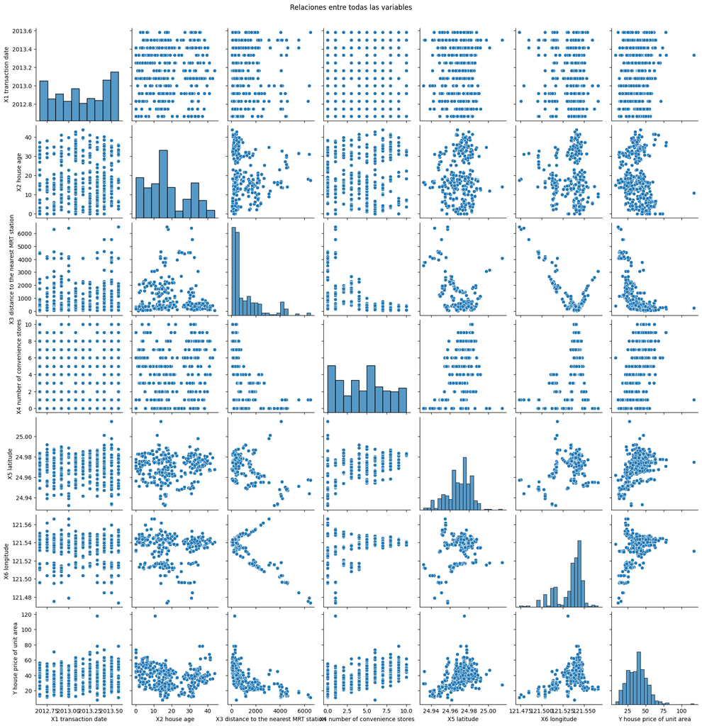

```python
sns.pairplot(real_state)
plt.suptitle('Relaciones entre todas las variables', y=1.02)
plt.show()
```

```python
#dividir datos

predictoras = real_state.drop('Y house price of unit area', axis=1)
objetivo = real_state['Y house price of unit area']

predictoras_train, predictoras_test, objetivo_train, objetivo_test = train_test_split(
    predictoras, objetivo, test_size=0.3, random_state=42
)

print(f"Tamaño de entrenamiento: {predictoras_train.shape[0]} muestras")
print(f"Tamaño de prueba: {predictoras_test.shape[0]} muestras")
```

```
Tamaño de entrenamiento: 289 muestras
Tamaño de prueba: 125 muestras
```

```python
# Modelo de regresión con todas las predictoras
modeloRS=LinearRegression()
modeloRS.fit(predictoras_train, objetivo_train)

coeficientes_realstate = pd.DataFrame({
    'Variable': predictoras_train.columns,
    'Coeficiente': modeloRS.coef_
})

print("=== COEFICIENTES DEL MODELO ===\n")
print(coeficientes_realstate)
print(f"\nIntercept (término constante): {modeloRS.intercept_:.4f}")
```

```
=== COEFICIENTES DEL MODELO ===

                                 Variable  Coeficiente
0                     X1 transaction date     5.847797
1                            X2 house age    -0.242546
2  X3 distance to the nearest MRT station    -0.005139
3         X4 number of convenience stores     1.074495
4                             X5 latitude   239.096949
5                            X6 longitude   -52.235159

Intercept (término constante): -11350.7405
```

```python
# Evaluar modelo completo
objetivo_pred = modeloRS.predict(predictoras_test)

MAE = metrics.mean_absolute_error(objetivo_test, objetivo_pred)
MSE = metrics.mean_squared_error(objetivo_test, objetivo_pred)
RMSE = np.sqrt(MSE)
R2 = metrics.r2_score(objetivo_test, objetivo_pred)

print("=== MÉTRICAS DE EVALUACIÓN ===\n")
print(f"Error Absoluto Medio (MAE): {MAE:.4f}")
print(f"Error Cuadrático Medio (MSE): {MSE:.4f}")
print(f"Raíz del Error Cuadrático Medio (RMSE): {RMSE:.4f}")
print(f"R² (Coeficiente de Determinación): {R2:.4f}")
```

```
=== MÉTRICAS DE EVALUACIÓN ===

Error Absoluto Medio (MAE): 6.1848
Error Cuadrático Medio (MSE): 73.5684
Raíz del Error Cuadrático Medio (RMSE): 8.5772
R² (Coeficiente de Determinación): 0.5601
```

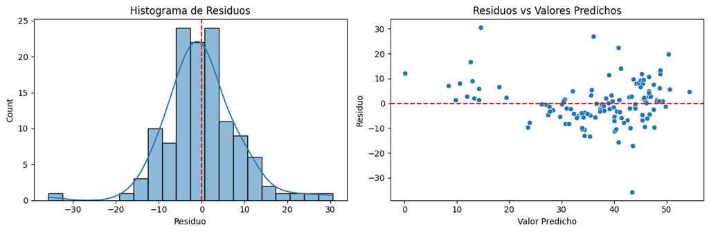

```python
# Análisis de residuos
residuos = objetivo_test - objetivo_pred

plt.figure(figsize=(12, 4))

plt.subplot(1, 2, 1)
sns.histplot(residuos, kde=True, bins=20)
plt.axvline(x=0, color='r', linestyle='--')
plt.title('Histograma de Residuos')
plt.xlabel('Residuo')

plt.subplot(1, 2, 2)
sns.scatterplot(x=objetivo_pred, y=residuos)
plt.axhline(y=0, color='r', linestyle='--')
plt.title('Residuos vs Valores Predichos')
plt.xlabel('Valor Predicho')
plt.ylabel('Residuo')

plt.tight_layout()
```

```python
#calculo VIF
X_constant = sm.add_constant(predictoras)
vif_data = pd.DataFrame()
vif_data["Variable"] = X_constant.columns
vif_data["VIF"] = [variance_inflation_factor(X_constant.values, i)
                   for i in range(X_constant.shape[1])]

print("=== FACTOR DE INFLACIÓN DE LA VARIANZA (VIF) ===\n")
print(vif_data)
print("\n Recuerda:")
print("- VIF > 5: indica alta multicolinealidad")
print("- VIF > 10: indica multicolinealidad severa")
```

```
=== FACTOR DE INFLACIÓN DE LA VARIANZA (VIF) ===

                                 Variable           VIF
0                                   const  2.422512e+08
1                     X1 transaction date  1.014674e+00
2                            X2 house age  1.014287e+00
3  X3 distance to the nearest MRT station  4.323019e+00
4         X4 number of convenience stores  1.617038e+00
5                             X5 latitude  1.610234e+00
6                            X6 longitude  2.926302e+00

 Recuerda:
- VIF > 5: indica alta multicolinealidad
- VIF > 10: indica multicolinealidad severa
```

```python
#foward selection
def forward_selection(X, y, threshold=0.05):
    """
    Selección de variables hacia adelante basada en p-valor
    """
    included = []
    while True:
        changed = False
        excluded = list(set(X.columns) - set(included))
        new_pval = pd.Series(index=excluded, dtype=float)

        for new_col in excluded:
            model = sm.OLS(y, sm.add_constant(pd.DataFrame(X[included + [new_col]]))).fit()
            new_pval[new_col] = model.pvalues[new_col]

        best_pval = new_pval.min()
        if best_pval < threshold:
            best_feature = new_pval.idxmin()
            included.append(best_feature)
            changed = True

        if not changed:
            break

    return included

print("=== SELECCIÓN HACIA ADELANTE ===\n")
variables_seleccionadas = forward_selection(predictoras, objetivo)
print(f"Variables seleccionadas: {variables_seleccionadas}")
```

```
=== SELECCIÓN HACIA ADELANTE ===

Variables seleccionadas: ['X3 distance to the nearest MRT station', 'X4 number of convenience stores', 'X2 house age', 'X5 latitude', 'X1 transaction date']
```

```python
# Comparación de modelos con diferentes variables
print("=== COMPARACIÓN DE MODELOS ===\n")

combinaciones = [
    ['X3 distance to the nearest MRT station'],
    ['X3 distance to the nearest MRT station', 'X4 number of convenience stores'],
    ['X3 distance to the nearest MRT station', 'X4 number of convenience stores', 'X2 house age'],
    ['X3 distance to the nearest MRT station', 'X4 number of convenience stores', 'X2 house age', 'X5 latitude'],
    ['X3 distance to the nearest MRT station', 'X4 number of convenience stores', 'X2 house age', 'X5 latitude', 'X1 transaction date'],
    variables_seleccionadas
]

nombres_combinaciones = [
    'Modelo 1: x3',
    'Modelo 2: x3 + x4',
    'Modelo 3: x3 + x4 + x2',
    'Modelo 4: x3 + x4 + x2 + x5',
    'Modelo 5: x3 + x4 + x2 + x5 + x1',
    'Modelo 6: variavles seleccionadas por foward'
]

for nombre, vars_list in zip(nombres_combinaciones, combinaciones):
    X_sel = sm.add_constant(predictoras[vars_list])
    model = sm.OLS(objetivo, X_sel).fit()

    print(f"📊 {nombre}")
    print(f"  Variables: {vars_list}")
    print(f"  R² = {model.rsquared:.4f}")
    print(f"  R² ajustado = {model.rsquared_adj:.4f}")
    print(f"  AIC = {model.aic:.2f}")
    print(f"  BIC = {model.bic:.2f}")
    print()
```

```
=== COMPARACIÓN DE MODELOS ===

📊 Modelo 1: x3
  Variables: ['X3 distance to the nearest MRT station']
  R² = 0.4538
  R² ajustado = 0.4524
  AIC = 3089.07
  BIC = 3097.12

📊 Modelo 2: x3 + x4
  Variables: ['X3 distance to the nearest MRT station', 'X4 number of convenience stores']
  R² = 0.4966
  R² ajustado = 0.4941
  AIC = 3057.28
  BIC = 3069.36

📊 Modelo 3: x3 + x4 + x2
  Variables: ['X3 distance to the nearest MRT station', 'X4 number of convenience stores', 'X2 house age']
  R² = 0.5411
  R² ajustado = 0.5377
  AIC = 3020.97
  BIC = 3037.08

📊 Modelo 4: x3 + x4 + x2 + x5
  Variables: ['X3 distance to the nearest MRT station', 'X4 number of convenience stores', 'X2 house age', 'X5 latitude']
  R² = 0.5711
  R² ajustado = 0.5669
  AIC = 2994.91
  BIC = 3015.04

📊 Modelo 5: x3 + x4 + x2 + x5 + x1
  Variables: ['X3 distance to the nearest MRT station', 'X4 number of convenience stores', 'X2 house age', 'X5 latitude', 'X1 transaction date']
  R² = 0.5823
  R² ajustado = 0.5772
  AIC = 2985.99
  BIC = 3010.15

📊 Modelo 6: variavles seleccionadas por foward
  Variables: ['X3 distance to the nearest MRT station', 'X4 number of convenience stores', 'X2 house age', 'X5 latitude', 'X1 transaction date']
  R² = 0.5823
  R² ajustado = 0.5772
  AIC = 2985.99
  BIC = 3010.15
```

```python
# Análisis detallado del mejor modelo
print("=== MEJOR MODELO SEGÚN FORWARD SELECTION ===\n")

X_sel = sm.add_constant(predictoras[variables_seleccionadas])
modelo_final = sm.OLS(objetivo, X_sel).fit()
print(modelo_final.summary())
```

```
=== MEJOR MODELO SEGÚN FORWARD SELECTION ===

                                OLS Regression Results
======================================================================================
Dep. Variable:     Y house price of unit area   R-squared:                       0.582
Model:                                    OLS   Adj. R-squared:                  0.577
Method:                         Least Squares   F-statistic:                     113.8
Date:                        Thu, 17 Sep 2026   Prob (F-statistic):           4.47e-75
Time:                                21:20:47   Log-Likelihood:                -1487.0
No. Observations:                         414   AIC:                             2986.
Df Residuals:                             408   BIC:                             3010.
Df Model:                                   5
Covariance Type:                    nonrobust
==========================================================================================================
                                             coef    std err          t      P>|t|      [0.025      0.975]
----------------------------------------------------------------------------------------------------------
const                                  -1.596e+04   3233.450     -4.936      0.000   -2.23e+04   -9602.961
X3 distance to the nearest MRT station    -0.0044      0.000     -8.887      0.000      -0.005      -0.003
X4 number of convenience stores            1.1361      0.188      6.056      0.000       0.767       1.505
X2 house age                              -0.2694      0.038     -7.003      0.000      -0.345      -0.194
X5 latitude                              226.8816     44.174      5.136      0.000     140.044     313.719
X1 transaction date                        5.1348      1.555      3.303      0.001       2.079       8.191
==============================================================================
Omnibus:                      232.810   Durbin-Watson:                   2.154
Prob(Omnibus):                  0.000   Jarque-Bera (JB):             3644.713
Skew:                           2.038   Prob(JB):                         0.00
Kurtosis:                      16.953   Cond. No.                     1.77e+07
==============================================================================

Notes:
[1] Standard Errors assume that the covariance matrix of the errors is correctly specified.
[2] The condition number is large, 1.77e+07. This might indicate that there are
strong multicollinearity or other numerical problems.
```

```python
# Evaluación del mejor modelo en test
predictoras_train_sel = predictoras_train[variables_seleccionadas]
predictoras_test_sel = predictoras_test[variables_seleccionadas]

modelo_sel = LinearRegression()
modelo_sel.fit(predictoras_train_sel, objetivo_train)

objetivo_pred_sel = modelo_sel.predict(predictoras_test_sel)

MAE_sel = metrics.mean_absolute_error(objetivo_test, objetivo_pred_sel)
MSE_sel = metrics.mean_squared_error(objetivo_test, objetivo_pred_sel)
RMSE_sel = np.sqrt(MSE_sel)
R2_sel = metrics.r2_score(objetivo_test, objetivo_pred_sel)

print("=== COMPARACIÓN DE RENDIMIENTO ===\n")
print("Modelo Completo vs Modelo Seleccionado:")

print(f"\nModelo Completo (todas las variables):")
print(f"  MAE: {MAE:.4f}")
print(f"  RMSE: {RMSE:.4f}")
print(f"  R²: {R2:.4f}")

print(f"\nModelo Seleccionado ({variables_seleccionadas}):")
print(f"  MAE: {MAE_sel:.4f}")
print(f"  RMSE: {RMSE_sel:.4f}")
print(f"  R²: {R2_sel:.4f}")
```

```
=== COMPARACIÓN DE RENDIMIENTO ===

Modelo Completo vs Modelo Seleccionado:

Modelo Completo (todas las variables):
  MAE: 6.1848
  RMSE: 8.5772
  R²: 0.5601

Modelo Seleccionado (['X3 distance to the nearest MRT station', 'X4 number of convenience stores', 'X2 house age', 'X5 latitude', 'X1 transaction date']):
  MAE: 6.1424
  RMSE: 8.5266
  R²: 0.5652
```

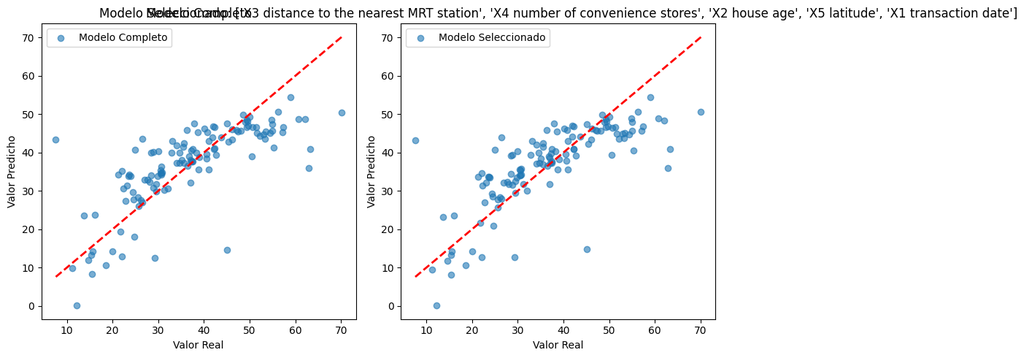

```python
# Visualización del modelo seleccionado
plt.figure(figsize=(10, 5))

plt.subplot(1, 2, 1)
plt.scatter(objetivo_test, objetivo_pred, alpha=0.6, label='Modelo Completo')
plt.plot([objetivo_test.min(), objetivo_test.max()], [objetivo_test.min(), objetivo_test.max()], 'r--', lw=2)
plt.xlabel('Valor Real')
plt.ylabel('Valor Predicho')
plt.title('Modelo Completo')
plt.legend()

plt.subplot(1, 2, 2)
plt.scatter(objetivo_test, objetivo_pred_sel, alpha=0.6, label='Modelo Seleccionado')
plt.plot([objetivo_test.min(), objetivo_test.max()], [objetivo_test.min(), objetivo_test.max()], 'r--', lw=2)
plt.xlabel('Valor Real')
plt.ylabel('Valor Predicho')
plt.title(f'Modelo Seleccionado: {variables_seleccionadas}')
plt.legend()

plt.tight_layout()
plt.show()
```

Gracias a las resultados del foward selection se puede concluir que la úunica variable que no es necesaria para la regresión es X6: Longitud, ya que al agregar esta variable realmente no mejora el modelo de forma relevante y en la comparaci+on de modelos los mejores R cuadrado y R cuadrado ajustado se van para el modelo con las variables : 'X3 distance to the nearest MRT station', 'X4 number of convenience stores', 'X2 house age', 'X5 latitude' y 'X1 transaction date'